# Data Presentation Using Tables

Week 3

Published

October 3, 2025

# Before we start

- Any questions?
- For sampling hints for the next homework lab, look for Week 1 script.

[Download script](https://artur-baranov.github.io/nu-ps403-ds/scripts/ps403-d_03.qmd)

[Download data](https://artur-baranov.github.io/nu-ps403-ds/data/wvs.csv)

**Review**

First, load the `tidyverse` library

```r
library(tidyverse)
```

Then, load the V-Dem data

```r
load(url("https://github.com/vdeminstitute/vdemdata/raw/6bee8e170578fe8ccdc1414ae239c5e870996bc0/data/vdem.RData"))
```

You are interested in corruption in various geographical regions. Select year (`year`), region (`e_regionpol_7C`) and corruption (`v2x_corr`) variables from the `vdem` dataset.

```r
corruption_data = ... %>%
  ...(year, ..., v2x_corr)
```

As we are working with the V-Dem data, let’s rename variables so it’s more straightforward.

```r
corruption_data = corruption_data ...
  ...(region = e_regionpol_7C,
      corruption = ...)
```

Using `group_by()` and `summarize()` calculate the average corruption for all regions in the dataset.

```r
corruption_data ...
  (...) %>%
  ...(average = ...(..., na.rm = T))
```

Lastly, let’s see the distributions of corruption across regions. Draw a boxplot below with `region` variable on the X axis, and `corruption` variable on the Y axis.

```r
ggplot(data = corruption_data) +
  ...(aes(x = ..., y = ...))
```

Something is wrong, right? We haven’t checked the classes of the variables, and apparently the `region` variable has to be changed. Let’s check it’s class first.

```r
...(corruption_data$...)
```

What class should it be? Let’s recode it directly on the plot.

```r
...(...) +
  geom_boxplot(aes(x = ...(region), y = ...))
```

Finally, remove the data we worked with from the environment.

```r
rm(vdem, corruption_data)
```

# Agenda

- Summarizing Data
- Presenting Data with Tables

# Exploring Data

Today we are working with the World Values Survey data. You can find the codebook [here](https://www.worldvaluessurvey.org/WVSDocumentationWV7.jsp).

Load the data. Explore the dimensions. This is a smaller version of the dataset, the full one is available on the WVS [website](https://www.worldvaluessurvey.org/wvs.jsp).

```r
wvs = read.csv("data/wvs.csv")

ncol(wvs)
nrow(wvs)
```

```
[1] 4
[1] 97220
```

Explore the names of the variables.

```r
colnames(wvs)
```

```
[1] "B_COUNTRY_ALPHA" "Q108"            "Q191"            "Q194"
```

For your convenience, here is the variables’ description from the codebook:

- `B_COUNTRY_ALPHA` - country name
- `Q108` - Government´s vs individual´s responsibility (10 - people should take more responsibility to provide for themselves, 1 - the government should take more responsibility to ensure that everyone is provided for)
- `Q191` - Justifiable: Violence against other people (10 - justifiable, 1 - not justifiable)
- `Q194` - Justifiable: Political violence (10 - justifiable, 1 - not justifiable)

Let’s get the **range** of data. What does it mean?

```r
range(wvs$Q108)
```

```
[1] -5 10
```

Let’s double check with summary. Same! Take a look on the codebook.

```r
summary(wvs$Q108)
```

```
   Min. 1st Qu.  Median    Mean 3rd Qu.    Max.
 -5.000   2.000   5.000   4.945   7.000  10.000
```

For the purposes of this exercise, drop all missing or irrelevant answers (which you should be **very** careful erasing in real task).

```r
wvs = wvs %>%
  filter(Q108 > 0)
```

And for our convenience, rename the variables.

```r
wvs = wvs %>%
  rename(country = B_COUNTRY_ALPHA,
         responsibility = Q108,
         violence = Q191,
         political_violence = Q194)
```

# Presenting Data in a Table

Now, let’s present the descriptive statistics for the `responsibility` variable, but for each country. Again, tricky `group_by()` command! Make sure to include `mean()`, `sd()` and `median()`. [Again, here is a great explanation of what is going on](https://artur-baranov.github.io/images/groupby_sum_eng.png).

```r
responsibility_description = wvs %>%
  group_by(country) %>%
  summarize(average = mean(responsibility),
            sd = sd(responsibility),
            median = median(responsibility))

responsibility_description %>%
  head()
```

```
# A tibble: 6 × 4
  country average    sd median
  <chr>     <dbl> <dbl>  <dbl>
1 AND        4.47  2.67      4
2 ARG        5.02  2.69      5
3 ARM        4.18  3.41      4
4 AUS        5.34  2.78      5
5 BGD        4.26  2.91      4
6 BOL        5.74  3.06      6
```

Great! Now, let’s make publishable table to present the variable. However, focus only on Post-Soviet countries. Make sure to go through syntax!

```r
post_soviet = c("ARM", "AZE", "BLR", "EST", "GEO", "KAZ", "KGZ", "LVA", "LTU", "MDA", "RUS", "TJK",  "TKM", "UKR", "UZB")

post_soviet_responsibility = responsibility_description %>%
  filter(country %in% post_soviet)

post_soviet_responsibility
```

```
# A tibble: 7 × 4
  country average    sd median
  <chr>     <dbl> <dbl>  <dbl>
1 ARM        4.18  3.41      4
2 KAZ        4.91  2.81      5
3 KGZ        5.11  3.92      5
4 RUS        4.39  2.72      5
5 TJK        5.36  2.84      5
6 UKR        4.43  2.68      5
7 UZB        6.02  3.22      6
```

To make it publishable and visually appealing, load the `tinytable` library.

```r
library(tinytable)
```

Try it out! Looks great, but we can do more.

```r
post_soviet_responsibility %>%
  tt()
```

| country | average | sd | median |
| --- | --- | --- | --- |
| ARM | 4.177194 | 3.409121 | 4 |
| KAZ | 4.910256 | 2.808218 | 5 |
| KGZ | 5.107383 | 3.916236 | 5 |
| RUS | 4.393635 | 2.722294 | 5 |
| TJK | 5.359167 | 2.838171 | 5 |
| UKR | 4.429032 | 2.684628 | 5 |
| UZB | 6.022277 | 3.221572 | 6 |

Make sure to format it well. For example, capitalize the names of the columns. Other functions for changing the character case [here](https://stringr.tidyverse.org/reference/case.html) - you can apply it to observations, too.

```r
colnames(post_soviet_responsibility) = colnames(post_soviet_responsibility) %>%
  str_to_title()
```

```r
post_soviet_responsibility %>%
  tt(caption = "Descriptive Statistics for Post Soviet Region") %>%
  format_tt(digits = 2) %>%
  style_tt(i = c(2, 3, 5, 6), # rows
           j = 1:4,           # columns
           background = "teal",
           color = "white",
           bold = TRUE)
```

Descriptive Statistics for Post Soviet Region

| Country | Average | Sd | Median |
| --- | --- | --- | --- |
| ARM | 4.2 | 3.4 | 4 |
| KAZ | 4.9 | 2.8 | 5 |
| KGZ | 5.1 | 3.9 | 5 |
| RUS | 4.4 | 2.7 | 5 |
| TJK | 5.4 | 2.8 | 5 |
| UKR | 4.4 | 2.7 | 5 |
| UZB | 6 | 3.2 | 6 |

# Extra

Here’s another example of what you can do with this. First, prepare the data. Then, draw a `tinytable`. But this is **extra**!

```r
post_soviet_description = wvs %>%
  group_by(country) %>%
  summarize(average_r = mean(responsibility),
            sd_r = sd(responsibility),
            average_v = mean(violence),
            sd_v = sd(violence),
            average_pv = mean(political_violence),
            sd_pv = sd(political_violence)) %>%
  filter(country %in% post_soviet)

extra_table = post_soviet_description %>%
  tt() %>%
  group_tt(j = list("Responsibility" = 2:3,
                    "Violence" = 4:5,
                    "Political Violence" = 6:7)) %>%
  { colnames(.) = c("Country", "Average", "SD", "Average", "SD", "Average", "SD"); . } %>%
  format_tt(digits = 2) %>%        # round up to 2 digits
  style_tt(j = 2:7, align = "c")   # center columns

extra_table
```

[output not shown]

You even can add plots into the table! You can explore it [here](https://vincentarelbundock.github.io/tinytable).

Variables

Histogram

Density

Average

Responsibility

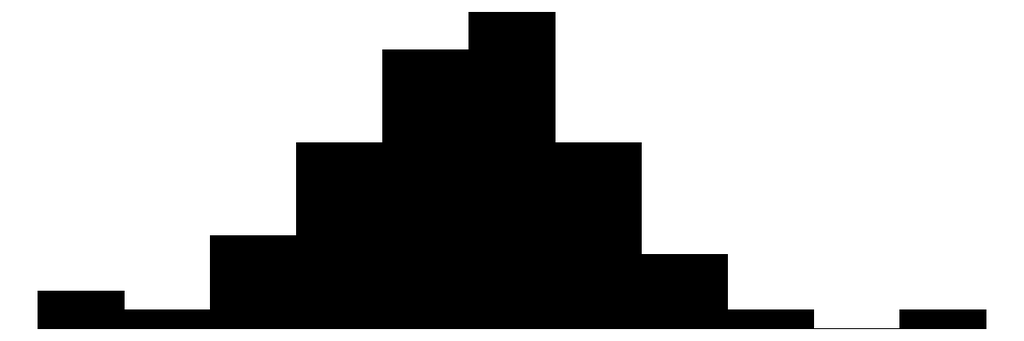

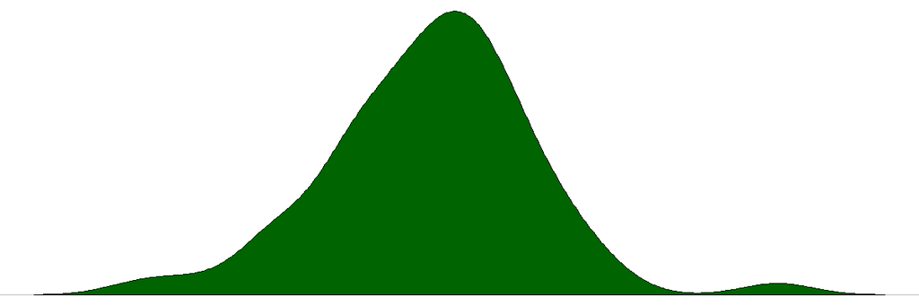

5

Violence

[figure not shown]

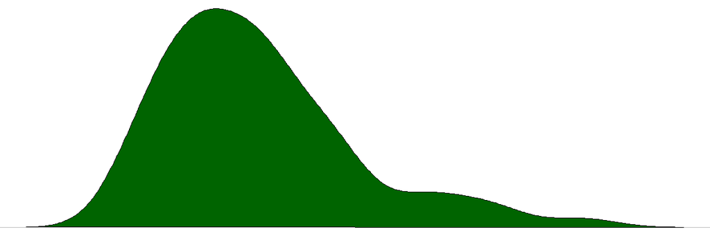

1.9

Political violence

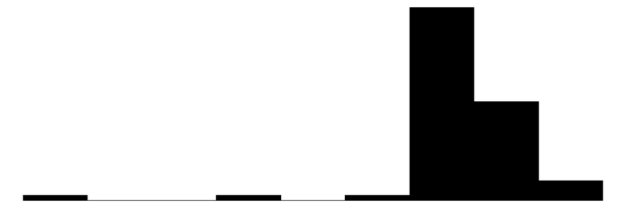

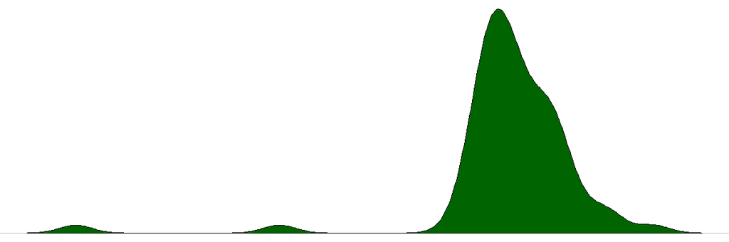

1.8

```r
# Calculate Average for each variable
variables_description = wvs %>%
  group_by(country) %>%
  summarize(responsibility = mean(responsibility),
            violence = mean(violence),
            political_violence = mean(political_violence))

# Create a list of these Averages
# (tinytable syntax requires a list for plots, not the dataframe)
plot_data = list(variables_description$responsibility,
                 variables_description$violence,
                 variables_description$political_violence)

# Create a placeholder table
dat = data.frame(Variables = c("Responsibility",
                               "Violence",
                               "Political violence"),
                 Histogram = "",
                 Density = "",
                 Average = c(mean(variables_description$responsibility),
                             mean(variables_description$violence),
                             mean(variables_description$political_violence)))

# Draw a table, fill in the plots. If images are not displaying, render the document!
tt(dat) %>%
  plot_tt(j = 2, fun = "histogram", data = plot_data) %>%
  plot_tt(j = 3, fun = "density", data = plot_data, color = "darkgreen") %>%
  style_tt(j = 2:3, align = "c") %>%
  format_tt(digits = 2)
```

# Check list

- I am confident in summarizing variables using combination of `group_by()` and `summarize()`
- I can present nice looking tables with `tinytable`
- I know how to use `%in%` operator to filter data

# Optional Exercises

Explore `violence` variable in `wvs` dataset. What is its range?

**Solution**

```r
...
```

Draw a histogram of `violence` variable using `ggplot()`.

**Solution**

```r
...
```

Anything strange? What does negative values stand for? Remove if needed.

**Solution**

```r
...
```

Present average and median for `violence` for each country.

**Solution**

```r
...
```

Now, present the data for Latin American countries using `tinytable`. Here is the vector for your convenience.

```r
latin_america <- c(
  "ARG",  # Argentina
  "BOL",  # Bolivia
  "BRA",  # Brazil
  "CHL",  # Chile
  "COL",  # Colombia
  "CRI",  # Costa Rica
  "CUB",  # Cuba
  "DOM",  # Dominican Republic
  "ECU",  # Ecuador
  "SLV",  # El Salvador
  "GTM",  # Guatemala
  "HND",  # Honduras
  "MEX",  # Mexico
  "NIC",  # Nicaragua
  "PAN",  # Panama
  "PRY",  # Paraguay
  "PER",  # Peru
  "URY",  # Uruguay
  "VEN"   # Venezuela
)
```

**Solution**

```r
...
```

Customize the `tinytable` so the columns look like titles. Highlight top-3 most violent countries with `red` color.

**Solution**

```r
...
```